# Cyclistic Case Study

Dylan Roberts

2023-1-2

## Introduction

### Background

Cyclistic is a bike-share company that offers different tiers of service: charging by the minute, buying a day pass, or annual memberships. Causal riders are those who either pay for individual rides by the minute, or buy day passes. Members are the riders who have annual memberships. Currently, only around 30% of users use the bikes to commute, while the rest use them for leisure.

### Business task

The director of Cyclistic wants to get as many people on annual memberships as possible because they believe that will bring the most profit. In order to get an idea of how marketing efforts should be focused, the data analyst team needs to find out the differences in how casual riders and members use their services.

### Data Sources

The data used for this analysis was retrieved from https://divvy-tripdata.s3.amazonaws.com/index.html. It comes from the bike share service Divvy, but we are using it as data for a fictional company called Cyclistic for the purpose of this case study. Motivate International Inc. has made this data available for use.

## Installing necessary packages and loading the data

First, we need to load the necessary packages and data to perform our analysis

```r
library(tidyverse)
```

```r
library(dplyr)
library(ggplot2)
library(janitor)
library(lubridate)
trip_11_2021 <- read.csv("G:/Google Data Course/Case Study/bike data/202111-divvy-tripdata.csv")
trip_12_2021 <- read.csv("G:/Google Data Course/Case Study/bike data/202112-divvy-tripdata.csv")
trip_1_2022 <- read.csv("G:/Google Data Course/Case Study/bike data/202201-divvy-tripdata.csv")
trip_2_2022 <- read.csv("G:/Google Data Course/Case Study/bike data/202202-divvy-tripdata.csv")
trip_3_2022 <- read.csv("G:/Google Data Course/Case Study/bike data/202203-divvy-tripdata.csv")
trip_4_2022 <- read.csv("G:/Google Data Course/Case Study/bike data/202204-divvy-tripdata.csv")
trip_5_2022 <- read.csv("G:/Google Data Course/Case Study/bike data/202205-divvy-tripdata.csv")
trip_6_2022 <- read.csv("G:/Google Data Course/Case Study/bike data/202206-divvy-tripdata.csv")
trip_7_2022 <- read.csv("G:/Google Data Course/Case Study/bike data/202207-divvy-tripdata.csv")
trip_8_2022 <- read.csv("G:/Google Data Course/Case Study/bike data/202208-divvy-tripdata.csv")
trip_9_2022 <- read.csv("G:/Google Data Course/Case Study/bike data/202209-divvy-tripdata.csv")
trip_10_2022 <- read.csv("G:/Google Data Course/Case Study/bike data/202210-divvy-tripdata.csv")

total_trips <- rbind(trip_11_2021,trip_12_2021,trip_1_2022,trip_2_2022,trip_3_2022,trip_4_2022,
                     trip_5_2022,trip_6_2022,trip_7_2022,trip_8_2022,trip_9_2022,trip_10_2022)
```

## Clean data and add new variables for analysis

Next, we need to clean up the data and record certain metrics needed for our analysis. To begin, we remove the latitude and longitude variables as these are not needed. Following this, we separate our time data into individual categories (date, month, day, year, day of week). The last variable to add is the ride length in seconds. Finally, we make a new data set that removes bikes taken by maintenance and negative ride lengths.

```r
total_trips <- total_trips %>%
  select(-c(start_lat, start_lng, end_lat, end_lng))

total_trips$started_at <- lubridate::ymd_hms(total_trips$started_at)
total_trips$ended_at <- lubridate::ymd_hms(total_trips$ended_at)

total_trips$start_hour <- lubridate::hour(total_trips$started_at)
total_trips$end_hour <- lubridate::hour(total_trips$ended_at)

total_trips$date <- as.Date(total_trips$started_at)
total_trips$month <- format(as.Date(total_trips$date), "%m")
total_trips$day <- format(as.Date(total_trips$date), "%d")
total_trips$year <- format(as.Date(total_trips$date), "%Y")
total_trips$day_of_week <- format(as.Date(total_trips$date), "%A")

total_trips$ride_length <- difftime(total_trips$ended_at,total_trips$started_at)

total_trips$ride_lengthS <- as.numeric(as.character(total_trips$ride_length))

total_trips_v2 <- total_trips[!(total_trips$start_station_name == "HQ QR" | total_trips$ride_length<0),]
```

## Analysis

To begin, let’s compare some summary statistics of casuals and members

```r
aggregate(total_trips_v2$ride_lengthS ~ total_trips_v2$member_casual, FUN = mean)
```

```
##   total_trips_v2$member_casual total_trips_v2$ride_lengthS
## 1                       casual                   1750.3054
## 2                       member                    762.8815
```

```r
aggregate(total_trips_v2$ride_lengthS ~ total_trips_v2$member_casual, FUN = median)
```

```
##   total_trips_v2$member_casual total_trips_v2$ride_lengthS
## 1                       casual                         790
## 2                       member                         530
```

```r
aggregate(total_trips_v2$ride_lengthS ~ total_trips_v2$member_casual, FUN = max)
```

```
##   total_trips_v2$member_casual total_trips_v2$ride_lengthS
## 1                       casual                     2483235
## 2                       member                       93594
```

```r
aggregate(total_trips_v2$ride_lengthS ~ total_trips_v2$member_casual, FUN = min)
```

```
##   total_trips_v2$member_casual total_trips_v2$ride_lengthS
## 1                       casual                           0
## 2                       member                           0
```

Now, let’s analyze ride length by weekday to see if we can identify any trends.

```r
aggregate(total_trips_v2$ride_lengthS ~ total_trips_v2$member_casual + total_trips_v2$day_of_week,
          FUN = mean)
```

```
##    total_trips_v2$member_casual total_trips_v2$day_of_week
## 1                        casual                     Friday
## 2                        member                     Friday
## 3                        casual                     Monday
## 4                        member                     Monday
## 5                        casual                   Saturday
## 6                        member                   Saturday
## 7                        casual                     Sunday
## 8                        member                     Sunday
## 9                        casual                   Thursday
## 10                       member                   Thursday
## 11                       casual                    Tuesday
## 12                       member                    Tuesday
## 13                       casual                  Wednesday
## 14                       member                  Wednesday
##    total_trips_v2$ride_lengthS
## 1                    1674.3550
## 2                     748.6522
## 3                    1757.6043
## 4                     737.7097
## 5                    1958.0404
## 6                     850.9703
## 7                    2031.1183
## 8                     844.7337
## 9                    1528.2472
## 10                    734.8682
## 11                   1561.1835
## 12                    728.1012
## 13                   1494.3808
## 14                    724.7810
```

## Visualizations

To better identify any trends, let’s visualize our data.

### Number of rides per weekday by type of rider

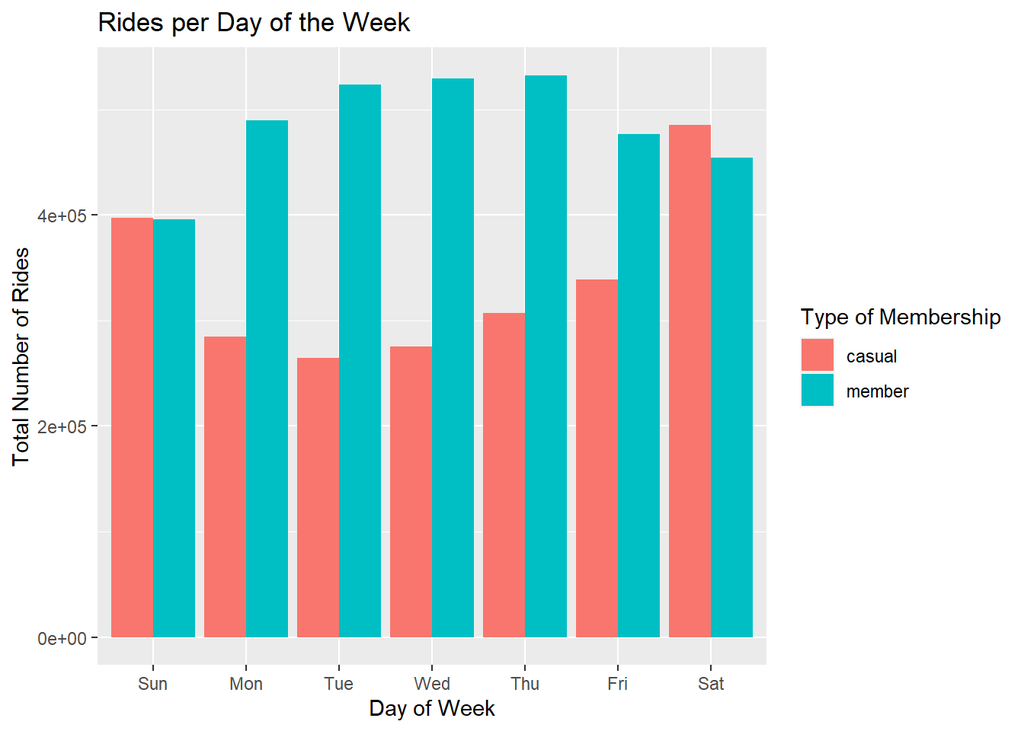

```r
total_trips_v2%>%
  mutate(weekday = wday(started_at, label = TRUE)) %>%
  group_by(member_casual, weekday) %>%
  summarise(number_of_rides = n()
            ,average_duration = mean(ride_length)) %>%
  arrange(member_casual, weekday) %>%
  ggplot(aes(x = weekday, y = number_of_rides, fill = member_casual)) +
  geom_col(position = "dodge") +
  labs(x = 'Day of Week', y = 'Total Number of Rides', title = 'Rides per Day of the Week', fill = 'Type of Membership')
```

As we can see in this visual, casual and member riders have inverted ride amounts throughout the week. This means that casual riders tend to be more active on the weekends and less active on weekdays, while members are more active throughout the week and less so on weekends. Interestingly, despite these trends, casuals and members share a similar number of rides on the weekends, suggesting that most people who use this service enjoy using it for leisure regardless of membership status.

### Number of rides per month by type of rider

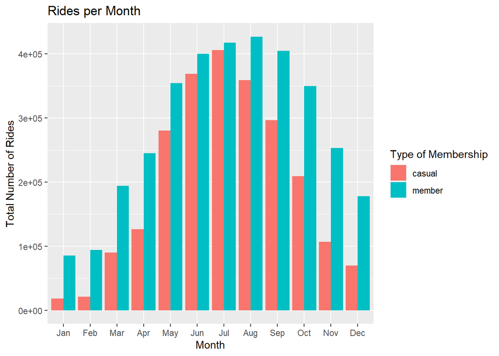

```r
total_trips_v2%>%
  mutate(month = month(started_at, label = TRUE)) %>%
  group_by(member_casual, month) %>%
  summarise(number_of_rides = n()
            ,average_duration = mean(ride_length)) %>%
  arrange(member_casual, month) %>%
  ggplot(aes(x = month, y = number_of_rides, fill = member_casual)) +
  geom_col(position = "dodge") +
  labs(x = 'Month', y = 'Total Number of Rides', title = 'Rides per Month', fill = 'Type of Membership')
```

### Average ride duration per Day of the Week

```
## Defaulting to continuous.
```

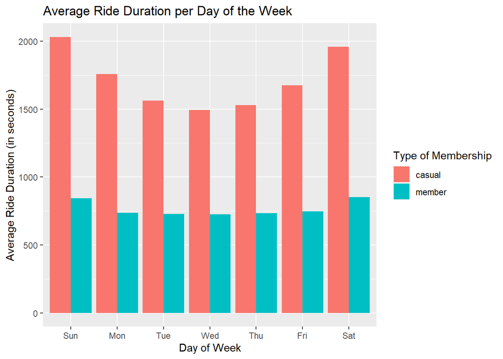

```r
total_trips_v2%>%
  mutate(weekday = wday(started_at, label = TRUE)) %>%
  group_by(member_casual, weekday) %>%
  summarise(number_of_rides = n()
            ,average_duration = mean(ride_length)) %>%
  arrange(member_casual, weekday) %>%
  ggplot(aes(x = weekday, y = average_duration, fill = member_casual)) +
  geom_col(position = "dodge") +
  labs(x = 'Day of Week', y = 'Average Ride Duration (in seconds)', title = 'Average Ride Duration per Day of the Week',
       fill = 'Type of Membership')
```

This visual illustrates the average ride duration for casuals and members by weekday. As discovered earlier, casuals clearly ride for much longer than members, especially on weekends. Additionally, casuals have more variance in ride times across the week, which lines up with the idea that members have a more consistent dependency on bikes than casuals.

## Conclusions and Recommendations

Given our results, there are a few potential marketing strategies Cyclistic could adopt to maximize profits.

The third and final marketing strategy would be to offer discounts on membership passes in the winter months. Lowering the price of a membership would increase demand for it when it would otherwise be low. Focusing on the long-term aspect of a yearly membership would cause more casual riders to justify their purchase. By causing casuals to simultaneously save money and be thinking out to the future, they will be more convinced that a membership is worth it for them. Additionally, since the overall popularity of rides would be low in the colder months anyway, it would be wise to secure more year-long commitments during this time.